# Bayesian spatial autoregression with missing data in “nimble”

Sudipto Banerjee

2023-10-17

0. The root directory for this project has 3 subfolders: “data”, “src” and “test”. The source Rmd file is in the “test” directory. The “data” directory contains the data sets for this linear regression example. The “src” directory contains an R program called “data_prep_areal.R” to prepare the data into nimble format.
1. Remove all objects from R workspace—good programming practice and can help debug your code better.

```r
rm(list = ls())
```

2. Prepare the data by running the “data_prep_areal.R” file in the “src” directory. When preparing the data, it is important to note that “nimble” expects the dependent random variable(s) being modeled to be stored as a separate object from the covariates and other fixed variables. So we create “nimbleData” to store the “Y” and “nimbleConstants” to store the fixed matrix of regressors “X” and other constants.

```r
source("../src/data_prep_areal_with_missing.R")
```

[output not shown]

```
## To access larger datasets in this package, install the spDataLarge
## package with: `install.packages('spDataLarge',
## repos='https://nowosad.github.io/drat/', type='source')`
```

```
## Spherical geometry (s2) switched off
```

```
## although coordinates are longitude/latitude, st_intersects assumes that they
## are planar
```

3. Load “nimble” and “coda” packages

```r
library(nimble)
library(coda)
```

4. The code in “data_prep_areal.R” creates “nimbleData” (Y), “nimbleConst” (X) and “nimbleInits”. For “nimbleInits”, apart from the different model parameters, we also initialize a variable “yFit” that represents the (posterior predictive) model-fitted distribution for each data point, i.e., “yFit[i] ~ dnorm(mu[i], tausq)” in the nimbleCode.

```r
attributes(nimbleData)
```

```
## $names
## [1] "Y"
```

```r
attributes(nimbleConstants)
```

```
## $names
## [1] "N" "p" "X"
```

```r
attributes(nimbleInits)
```

```
## $names
## [1] "beta"     "tausq"    "yFit"     "w"        "tausq_sp"
```

We will run 1 chain in our MCMC algorithm. We will need initial values for the model parameters.

5. Set the following variables:

```r
n_iter = 11000 ## Number of iterations
n_chains = 1 ## Number of different chains
n_burn = 1000 ## Number of initial runs ("burn" period) for MCMC to converge.
```

6. Define the model parameters to be recognized by the nimble model

```r
model_parameters = c("beta", "tausq", "sigma", "w", "sigma_sp", "yFit")
```

```r
adjInfo <- as.carAdjacency(A)
L <- length(adjInfo$adj)
nimbleConstants <- c(nimbleConstants, adjInfo, L=L)
```

```r
spCode <- nimbleCode({
        for (i in 1:N) {
                Y[i] ~ dnorm(mu[i], tausq)
                mu[i] <- inprod(X[i,1:p], beta[1:p]) + w[i]
            yFit[i] ~ dnorm(mu[i], tausq)
    }

    w[1:N] ~ dcar_normal(adj[1:L], weights[1:L], num[1:N], tausq_sp, zero_mean = 1)
    tausq_sp ~ dgamma(0.01, 0.01)
    sigma_sp <- 1/sqrt(tausq_sp)

    for (i in 1:p) { beta[i] ~ dflat()}
    tausq ~ dgamma(0.001, 0.001)
    sigma <- 1/sqrt(tausq)
}
)
```

8. Create the nimbleModel and run MCMC

```r
rModel <- nimbleModel(code = spCode, constants=nimbleConstants, data=nimbleData)
```

```
## Defining model
```

```
## Building model
```

```
## Setting data and initial values
```

```
## Running calculate on model
##   [Note] Any error reports that follow may simply reflect missing values in model variables.
```

```
## Checking model sizes and dimensions
```

```
##   [Note] This model is not fully initialized. This is not an error.
##          To see which variables are not initialized, use model$initializeInfo().
##          For more information on model initialization, see help(modelInitialization).
```

```r
mcmc.out <- nimbleMCMC(model = rModel, nchains=n_chains, inits=nimbleInits, niter = n_iter, nburnin=n_burn, monitor=model_parameters, samplesAsCodaMCMC = TRUE)
```

```
## Compiling
##   [Note] This may take a minute.
##   [Note] Use 'showCompilerOutput = TRUE' to see C++ compilation details.
```

```
## running chain 1...
```

```
## |-------------|-------------|-------------|-------------|
## |-------------------------------------------------------|
```

```r
##mcmc.out <- nimbleMCMC(code = spCode, constants=nimbleConstants, data=nimbleData, inits=nimbleInits, nchains=n_chains, niter = n_iter, nburnin=n_burn, monitor=model_parameters) ##The above two steps can be combined into one step
```

9. Attributes of mcmc.out

```r
attributes(mcmc.out)
```

```
## $dim
## [1] 10000   121
##
## $dimnames
## $dimnames[[1]]
## NULL
##
## $dimnames[[2]]
##   [1] "beta[1]"  "beta[2]"  "sigma"    "sigma_sp" "tausq"    "w[1]"
##   [7] "w[2]"     "w[3]"     "w[4]"     "w[5]"     "w[6]"     "w[7]"
##  [13] "w[8]"     "w[9]"     "w[10]"    "w[11]"    "w[12]"    "w[13]"
##  [19] "w[14]"    "w[15]"    "w[16]"    "w[17]"    "w[18]"    "w[19]"
##  [25] "w[20]"    "w[21]"    "w[22]"    "w[23]"    "w[24]"    "w[25]"
##  [31] "w[26]"    "w[27]"    "w[28]"    "w[29]"    "w[30]"    "w[31]"
##  [37] "w[32]"    "w[33]"    "w[34]"    "w[35]"    "w[36]"    "w[37]"
##  [43] "w[38]"    "w[39]"    "w[40]"    "w[41]"    "w[42]"    "w[43]"
##  [49] "w[44]"    "w[45]"    "w[46]"    "w[47]"    "w[48]"    "w[49]"
##  [55] "w[50]"    "w[51]"    "w[52]"    "w[53]"    "w[54]"    "w[55]"
##  [61] "w[56]"    "w[57]"    "w[58]"    "yFit[1]"  "yFit[2]"  "yFit[3]"
##  [67] "yFit[4]"  "yFit[5]"  "yFit[6]"  "yFit[7]"  "yFit[8]"  "yFit[9]"
##  [73] "yFit[10]" "yFit[11]" "yFit[12]" "yFit[13]" "yFit[14]" "yFit[15]"
##  [79] "yFit[16]" "yFit[17]" "yFit[18]" "yFit[19]" "yFit[20]" "yFit[21]"
##  [85] "yFit[22]" "yFit[23]" "yFit[24]" "yFit[25]" "yFit[26]" "yFit[27]"
##  [91] "yFit[28]" "yFit[29]" "yFit[30]" "yFit[31]" "yFit[32]" "yFit[33]"
##  [97] "yFit[34]" "yFit[35]" "yFit[36]" "yFit[37]" "yFit[38]" "yFit[39]"
## [103] "yFit[40]" "yFit[41]" "yFit[42]" "yFit[43]" "yFit[44]" "yFit[45]"
## [109] "yFit[46]" "yFit[47]" "yFit[48]" "yFit[49]" "yFit[50]" "yFit[51]"
## [115] "yFit[52]" "yFit[53]" "yFit[54]" "yFit[55]" "yFit[56]" "yFit[57]"
## [121] "yFit[58]"
##
##
## $mcpar
## [1]     1 10000     1
##
## $class
## [1] "mcmc"
```

10. Extract posterior samples:

```r
samps <- as.matrix(mcmc.out)
dim(samps)
```

```
## [1] 10000   121
```

13. Obtain medians and 95% credible intervals for these samples

```r
credibleIntervals <- t(apply(samps, 2, function(x){quantile(x, c(0.50, 0.025, 0.975))}))
```

14. Extract credible intervals for specific variable(s):

```r
CI_beta <- credibleIntervals[grep("beta", rownames(credibleIntervals)),]
CI_beta
```

```
##               50%      2.5%     97.5%
## beta[1] 24.637061 18.170525 30.738171
## beta[2]  1.454828  1.040344  1.899857
```

```r
CI_sigma <- credibleIntervals[grep("sigma", rownames(credibleIntervals)),]
CI_sigma
```

```
##               50%      2.5%    97.5%
## sigma    5.657310 2.2013137  7.79445
## sigma_sp 4.265826 0.8049587 12.18414
```

```r
CI_sigma_sp <- credibleIntervals[grep("sigma_sp", rownames(credibleIntervals)),]
CI_sigma_sp
```

```
##        50%       2.5%      97.5%
##  4.2658257  0.8049587 12.1841354
```

```r
CI_w <- credibleIntervals[grep("w", rownames(credibleIntervals)),]
CI_w
```

```
##              50%       2.5%      97.5%
## w[1]   0.2000028  -4.098011  5.4930466
## w[2]  -0.3204986  -8.592806  5.3335248
## w[3]   0.3419157  -5.242175  9.0945222
## w[4]   1.7099415  -1.243513 10.7429929
## w[5]   0.2427333  -3.693971  5.7746380
## w[6]   1.0933631  -2.249602  7.1937650
## w[7]   0.5234165  -3.271912  6.2604086
## w[8]  -1.1375163 -11.424399  3.7856716
## w[9]   0.4298149  -5.690046  9.7066787
## w[10] -1.6975899  -9.347127  0.9972255
## w[11]  1.2305596  -2.914927 10.9645455
## w[12]  1.4993048  -2.379992 10.2553166
## w[13] -0.3963568  -6.644272  5.7400555
## w[14] -0.5795668  -5.843266  3.7827673
## w[15] -0.9044730  -7.362097  3.0217321
## w[16] -1.4775616  -8.084261  1.8306097
## w[17]  2.2430175  -1.032281 11.4839777
## w[18] -0.7436774  -7.450351  2.9760987
## w[19] -1.3244674  -7.905604  2.4837061
## w[20] -1.2438461 -12.210654  2.3907735
## w[21] -0.1849769  -7.233093  6.1024370
## w[22] -1.5319581 -10.101305  1.8214316
## w[23]  1.1645653  -1.941027  7.1299287
## w[24] -0.6497883  -5.621533  2.4327692
## w[25] -1.1216630  -9.224118  2.9355134
## w[26] -2.6264163 -16.497279  0.9167847
## w[27] -1.0625498  -7.024543  2.0092442
## w[28]  1.4144563  -3.034151 12.4718681
## w[29] -0.9398342  -8.877983  2.8747025
## w[30] -0.6974742  -6.389565  3.8889186
## w[31]  1.2107307  -1.803146  8.9372206
## w[32] -0.3056700  -6.089319  3.2854359
## w[33] -0.4266879  -8.188776  7.1922110
## w[34]  0.8619699  -2.181582  8.8759985
## w[35] -0.4075479  -5.265176  3.7182445
## w[36] -0.8759864  -6.185421  2.8003122
## w[37]  0.1777160  -4.915684  6.6747615
## w[38]  2.2669459  -3.032189 11.5758864
## w[39]  0.8623363  -1.757159  7.9061019
## w[40] -0.7277322  -6.138459  3.3267639
## w[41]  1.3310754  -2.722880  9.6067882
## w[42] -0.7849626  -6.906570  3.6664626
## w[43]  0.2058183  -3.237768  5.5538721
## w[44] -0.4585338  -5.963102  3.9458472
## w[45]  0.5840453  -3.509852  6.5485388
## w[46] -2.4682591 -19.012841  1.7112326
## w[47]  0.1336194  -7.367401  6.6061262
## w[48]  2.1259704  -1.196858 11.4486471
## w[49]  0.9886167  -4.328897 10.8215615
## w[50] -0.1791044  -4.384234  3.7407254
## w[51]  1.4667785  -1.282031  8.3217332
## w[52]  0.7415578  -4.009868  8.3167137
## w[53]  0.5755063  -3.969128  6.1367158
## w[54] -0.9328931 -10.161998  4.3981717
## w[55] -0.7740678  -9.254314  2.9182272
## w[56] -0.6644602  -6.467031  4.1013651
## w[57]  1.3739953  -1.487135  7.4655722
## w[58]  0.8708778  -2.529526  7.7914002
```

```r
CI_yFit <- credibleIntervals[grep("yFit", rownames(credibleIntervals)),]
CI_yFit
```

```
##               50%     2.5%    97.5%
## yFit[1]  41.70074 29.66971 53.65078
## yFit[2]  42.28200 29.65203 54.96108
## yFit[3]  43.78978 30.82486 56.52201
## yFit[4]  51.01843 36.81094 62.71939
## yFit[5]  43.75104 31.05911 55.32636
## yFit[6]  54.03692 41.49149 65.99574
## yFit[7]  43.95759 31.68087 55.82553
## yFit[8]  57.87610 45.51576 72.17674
## yFit[9]  48.75303 35.95197 61.94067
## yFit[10] 49.35576 38.16118 62.94982
## yFit[11] 54.26518 41.04248 67.55199
## yFit[12] 48.42672 34.34080 59.90005
## yFit[13] 38.95773 26.53890 51.85548
## yFit[14] 42.24917 30.15589 54.16390
## yFit[15] 44.64999 32.76614 57.40391
## yFit[16] 42.53181 30.85548 55.80762
## yFit[17] 65.64169 50.68647 77.65893
## yFit[18] 45.38915 33.60590 58.03848
## yFit[19] 39.29397 27.82233 52.26138
## yFit[20] 37.53550 24.08349 51.06965
## yFit[21] 37.01957 24.69485 50.98099
## yFit[22] 49.57917 37.96438 63.67357
## yFit[23] 48.33035 35.40329 59.90212
## yFit[24] 47.48324 35.66960 59.68870
## yFit[25] 44.67264 33.00070 58.55256
## yFit[26] 37.87024 23.99236 53.12397
## yFit[27] 38.32952 26.93194 51.09069
## yFit[28] 49.95962 36.18251 63.50479
## yFit[29] 44.75422 33.48397 58.57358
## yFit[30] 39.80475 27.75153 52.31071
## yFit[31] 40.25427 26.90207 51.64490
## yFit[32] 45.94841 34.73122 58.84579
## yFit[33] 41.24781 28.19657 54.20606
## yFit[34] 49.55918 36.35594 62.09879
## yFit[35] 39.29392 27.19405 51.53769
## yFit[36] 43.54088 31.48531 55.94333
## yFit[37] 41.35454 28.01132 53.26626
## yFit[38] 43.76199 29.22247 56.01220
## yFit[39] 46.80229 33.77919 58.16014
## yFit[40] 42.50933 30.59621 54.40866
## yFit[41] 36.89703 23.34438 48.62729
## yFit[42] 39.66055 27.47542 52.17207
## yFit[43] 37.91498 25.28362 49.46170
## yFit[44] 39.07041 27.44572 51.83774
## yFit[45] 55.81706 42.53411 67.35431
## yFit[46] 41.89134 26.27157 58.02672
## yFit[47] 60.76539 47.35880 73.76670
## yFit[48] 45.09699 30.75959 57.12430
## yFit[49] 44.94357 31.66398 58.30697
## yFit[50] 48.39224 36.63127 60.51881
## yFit[51] 48.90971 35.76501 60.39304
## yFit[52] 53.51138 40.51560 65.62318
## yFit[53] 61.41050 48.02483 73.68796
## yFit[54] 47.58975 34.50216 60.82981
## yFit[55] 50.81505 38.59739 64.05815
## yFit[56] 38.87945 26.54265 51.44544
## yFit[57] 43.60336 30.63844 55.61369
## yFit[58] 58.92300 45.33508 70.43080
```

```r
library(maps)
library(ggplot2)
library(RColorBrewer)
library(dplyr)
library(tidyr)
library(classInt)
```

16. Extract map of California from “maps” library.

```r
caCounty = map("county","california", fill=TRUE, plot=FALSE)
countyID <- sapply(strsplit(caCounty$names, ","), function(x) x[2])
caCountySF <- st_as_sf(caCounty)
```

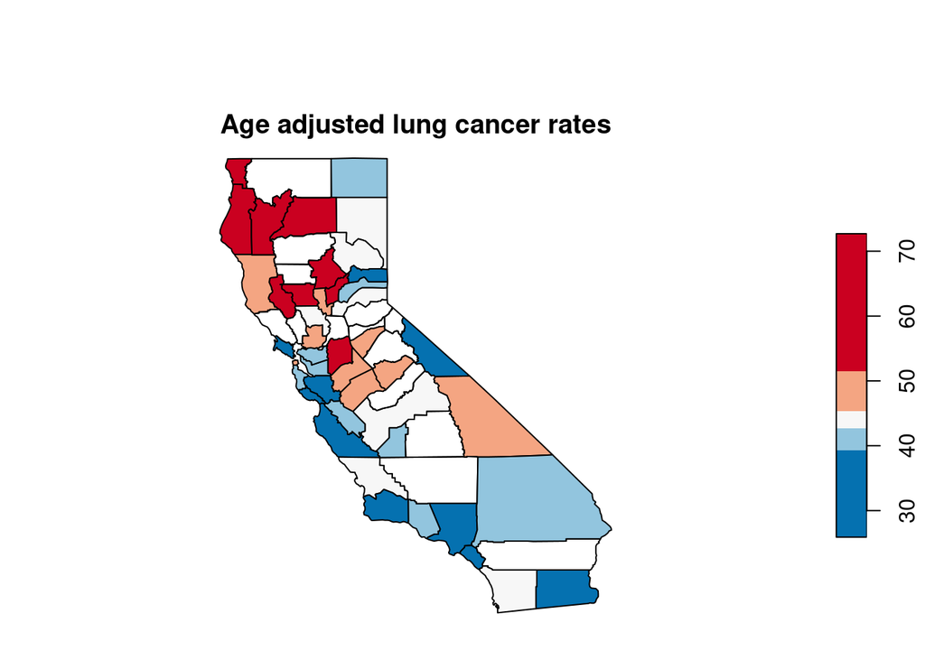

```r
yFitPosteriorMedians <- CI_yFit[,grep("50%", colnames(CI_yFit))]
caCountySF$ModelFitted <- yFitPosteriorMedians
caCountySF$ObsData <- Y
brksModelFitted = quantile(caCountySF$ModelFitted, c(0, 0.2, 0.4, 0.6, 0.8, 1))
brksObsData = quantile(caCountySF$ObsData, c(0, 0.2, 0.4, 0.6, 0.8, 1), na.rm=TRUE)

colorPalette = rev(brewer.pal(5,"RdBu"))

par(mfrow=c(1,2), oma = c(0,0,4,0) + 0.1, mar = c(0,0,1,0) + 0.1)

plot(caCountySF["ObsData"], pal = colorPalette, breaks = brksObsData, main = "Age adjusted lung cancer rates")
```

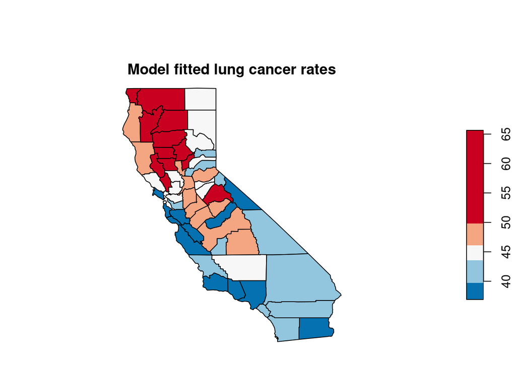

```r
plot(caCountySF["ModelFitted"], pal = colorPalette, breaks = brksModelFitted, main = "Model fitted lung cancer rates")
```